# Large Bayes Factors, but Zero in CrI

Minimal Working Example

Michael Vrazitulis

2024-05-26

In this document, I show the puzzling issue that I encountered when analyzing my master’s thesis data. In short, there are large Bayes factors (up to $BF_{10} = 18.8$) in cases where the 95% CrI of the parameter of interest includes zero.

For starters, let’s load `ggplot2` and `brms`:

```r
library(ggplot2)
library(brms)
```

Now we can load in the data set of interest. I’ve stripped it of anything but the columns necessary for downstream analysis.

(If you don’t have the TSV file at hand, here’s a download link: https://1drv.ms/u/s!AuRxgm6Ml5A4l9YMcP87g5RcUY-dYg?e=6vb4Me, 235.9 KiB)

```r
critical_results_SPV <- read.table(file = "critical_results_SPV.tsv", sep = "\t", header = TRUE)
```

How does this data look like? Let’s find out.

```r
str(critical_results_SPV)
```

```
## 'data.frame':    3173 obs. of  5 variables:
##  $ subject   : chr  "actual_2_s001" "actual_2_s001" "actual_2_s001" "actual_2_s001" ...
##  $ item      : chr  "possibility" "quantity" "space" "time" ...
##  $ VR        : num  0.412 -0.588 0.412 0.412 0.412 ...
##  $ POL       : num  0.498 0.498 0.498 0.498 -0.502 ...
##  $ res_log_RT: num  0.5454 0.3431 -0.0494 0.323 0.0445 ...
```

```r
summary(critical_results_SPV)
```

```
##    subject              item                 VR               POL
##  Length:3173        Length:3173        Min.   :-0.5878   Min.   :-0.5017
##  Class :character   Class :character   1st Qu.:-0.5878   1st Qu.:-0.5017
##  Mode  :character   Mode  :character   Median : 0.4122   Median : 0.4983
##                                        Mean   : 0.0000   Mean   : 0.0000
##                                        3rd Qu.: 0.4122   3rd Qu.: 0.4983
##                                        Max.   : 0.4122   Max.   : 0.4983
##    res_log_RT
##  Min.   :-1.14675
##  1st Qu.:-0.02181
##  Median : 0.30282
##  Mean   : 0.34191
##  3rd Qu.: 0.66634
##  Max.   : 2.27231
```

Clarifications:

The **subject** column contains IDs of the particular subjects.

The **item** column contains IDs of items. This experimental design has only four items.

The **VR** column contains the Good/Bad response provided by the subject.  
Here, Good is sum-coded as 0.412 and Bad is as –0.588.

The **POL** column contains information on whether we are in positive- or negative-polarity condition.  
Here, positive is sum-coded as 0.498 and negative as –0.502.

Finally, the **res_log_RT** column contains our dependent variable of interest (residual log RT).  
It was derived by first log-transforming raw RTs on the millisecond scale, then subtracting predicted log RTs produced by a model that had been fitted separately on control-condition trials.  
(In hindsight, I realize that this type of residualization preprocessing is kind of cringe, but I didn’t know that a year ago. Now it is what it is.)

As a sanity check, let’s look at how the dependent variable is distributed (histogram):

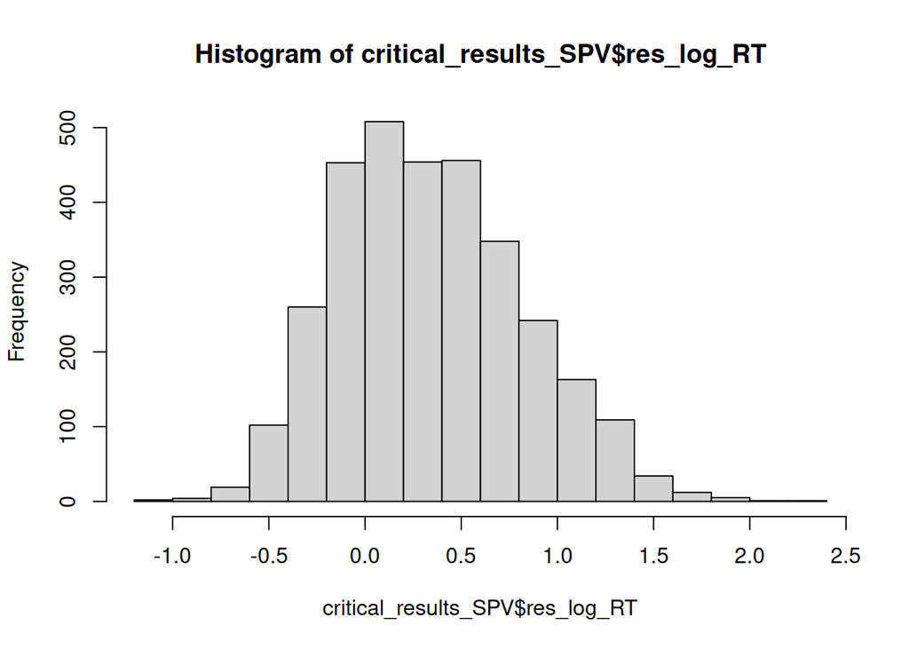

```r
hist(critical_results_SPV$res_log_RT)
```

At this point, we are ready to fit some `brms` models.

The hypothesis we want to test is that the interaction of VR (verification response) and POL (polarity) has a meaningful effect on residual log RTs. According to theory, we should expect a negative parameter value $\beta_{\mathtt{\,VR:POL}}$.

(Disclaimer: In order to ensure convergence, I fitted each of the models with 40k iterations! That takes forever, though, so I have set the code blocks below where models are fitted to `eval=FALSE`. But I provide a download link of an .RData file for each of the fitted models. So, in case you want to reproduce any downstream analyses *after* models have been fitted, feel free to just download my fitted models and load them into your workspace.)

```r
## null model (no population-level VR:POL), for comparison using Bayes factors

priors_null <-  c(
  prior(normal(0, 1), class = Intercept), # 0 because residual log RT
  prior(normal(0, 0.3), class = sigma),
  prior(normal(0, 0.2), class = b, coef = VR),
  prior(normal(0, 0.2), class = b, coef = POL),
  prior(normal(0, 0.1), class = sd),
  prior(lkj(2), class = cor)
)

fit_null <- brm('res_log_RT ~ VR + POL + (VR * POL | subject) + (VR * POL | item)',
                data = critical_results_SPV,
                family = gaussian(),
                prior = priors_null,
                chains = 4,
                cores = 12,
                iter = 40000,
                warmup = 8000,
                control = list(adapt_delta = 0.95),
                save_pars = save_pars(all = TRUE)
)
```

Download link for `fit_null`: https://1drv.ms/u/s!AuRxgm6Ml5A4l9YT6nAr7Y05C91zdA (3.8 GiB)

```r
## target parameter with prior N(0, 1)

priors_interest_prior_1 <- c(
  prior(normal(0, 1), class = Intercept), # 0 because residual log RT
  prior(normal(0, 0.3), class = sigma),
  prior(normal(0, 0.2), class = b, coef = VR),
  prior(normal(0, 0.2), class = b, coef = POL),
  prior(normal(0, 1), class = b, coef = VR:POL), # target!
  prior(normal(0, 0.1), class = sd),
  prior(lkj(2), class = cor)
)

fit_interest_prior_1 <- brm(res_log_RT ~ VR * POL + (VR * POL | subject) + (VR * POL | item),
                            data = critical_results_SPV,
                            family = gaussian(),
                            prior = priors_interest_prior_1,
                            chains = 4,
                            cores = 12,
                            iter = 40000,
                            warmup = 8000,
                            control = list(adapt_delta = .95),
                            save_pars = save_pars(all = TRUE)
)
```

Download link for `fit_interest_prior_1`: https://1drv.ms/u/s!AuRxgm6Ml5A4l9YVZdXjZ4MsyceBqQ?e=zRs6AM (3.8 GiB)

```r
## target parameter with prior N(0, 0.5)

priors_interest_prior_0_5 <- c(
  prior(normal(0, 1), class = Intercept), # 0 because residual log RT
  prior(normal(0, 0.3), class = sigma),
  prior(normal(0, 0.2), class = b, coef = VR),
  prior(normal(0, 0.2), class = b, coef = POL),
  prior(normal(0, 0.5), class = b, coef = VR:POL), # target!
  prior(normal(0, 0.1), class = sd),
  prior(lkj(2), class = cor)
)

fit_interest_prior_0_5 <- brm(res_log_RT ~ VR * POL + (VR * POL | subject) + (VR * POL | item),
                              data = critical_results_SPV,
                              family = gaussian(),
                              prior = priors_interest_prior_0_5,
                              chains = 4,
                              cores = 12,
                              iter = 40000,
                              warmup = 8000,
                              control = list(adapt_delta = .95),
                              save_pars = save_pars(all = TRUE)
)
```

Download link for `fit_interest_prior_0_5`: https://1drv.ms/u/s!AuRxgm6Ml5A4l9YQnHW07js2r_lXHQ?e=rYWPCT (3.8 GiB)

```r
## target parameter with prior N(0, 0.2)

priors_interest_prior_0_2 <- c(
  prior(normal(0, 1), class = Intercept), # 0 because residual log RT
  prior(normal(0, 0.3), class = sigma),
  prior(normal(0, 0.2), class = b, coef = VR),
  prior(normal(0, 0.2), class = b, coef = POL),
  prior(normal(0, 0.2), class = b, coef = VR:POL), # target!
  prior(normal(0, 0.1), class = sd),
  prior(lkj(2), class = cor)
)

fit_interest_prior_0_2 <- brm(res_log_RT ~ VR * POL + (VR * POL | subject) + (VR * POL | item),
                              data = critical_results_SPV,
                              family = gaussian(),
                              prior = priors_interest_prior_0_2,
                              chains = 4,
                              cores = 12,
                              iter = 40000,
                              warmup = 8000,
                              control = list(adapt_delta = .95),
                              save_pars = save_pars(all = TRUE)
)
```

Download link for `fit_interest_prior_0_2`: https://1drv.ms/u/s!AuRxgm6Ml5A4l9YPn7AuIWpVbe-pLQ?e=tgbxkt (3.8 GiB)

```r
## target parameter with prior N(0, 0.1)

priors_interest_prior_0_1 <- c(
  prior(normal(0, 1), class = Intercept), # 0 because residual log RT
  prior(normal(0, 0.3), class = sigma),
  prior(normal(0, 0.2), class = b, coef = VR),
  prior(normal(0, 0.2), class = b, coef = POL),
  prior(normal(0, 0.1), class = b, coef = VR:POL), # target!
  prior(normal(0, 0.1), class = sd),
  prior(lkj(2), class = cor)
)

fit_interest_prior_0_1 <- brm(res_log_RT ~ VR * POL + (VR * POL | subject) + (VR * POL | item),
                              data = critical_results_SPV,
                              family = gaussian(),
                              prior = priors_interest_prior_0_1,
                              chains = 4,
                              cores = 12,
                              iter = 40000,
                              warmup = 8000,
                              control = list(adapt_delta = .95),
                              save_pars = save_pars(all = TRUE)
)
```

Download link for `fit_interest_prior_0_1`: https://1drv.ms/u/s!AuRxgm6Ml5A4l9YSqygFgrJt9wD5rw?e=nxVJEr (3.8 GiB)

```r
## target parameter with prior N(0, 0.05)

priors_interest_prior_0_05 <- c(
  prior(normal(0, 1), class = Intercept), # 0 because residual log RT
  prior(normal(0, 0.3), class = sigma),
  prior(normal(0, 0.2), class = b, coef = VR),
  prior(normal(0, 0.2), class = b, coef = POL),
  prior(normal(0, 0.05), class = b, coef = VR:POL), # target!
  prior(normal(0, 0.1), class = sd),
  prior(lkj(2), class = cor)
)

fit_interest_prior_0_05 <- brm(res_log_RT ~ VR * POL + (VR * POL | subject) + (VR * POL | item),
                               data = critical_results_SPV,
                               family = gaussian(),
                               prior = priors_interest_prior_0_05,
                               chains = 4,
                               cores = 12,
                               iter = 40000,
                               warmup = 8000,
                               control = list(adapt_delta = .95),
                               save_pars = save_pars(all = TRUE)
)
```

Download link for `fit_interest_prior_0_05`: https://1drv.ms/u/s!AuRxgm6Ml5A4l9YUMqrpeMfDth4otw?e=pOvwKQ (3.8 GiB)

```r
## target parameter with prior N(0, 0.02)

priors_interest_prior_0_02 <- c(
  prior(normal(0, 1), class = Intercept), # 0 because residual log RT
  prior(normal(0, 0.3), class = sigma),
  prior(normal(0, 0.2), class = b, coef = VR),
  prior(normal(0, 0.2), class = b, coef = POL),
  prior(normal(0, 0.02), class = b, coef = VR:POL), # target!
  prior(normal(0, 0.1), class = sd),
  prior(lkj(2), class = cor)
)

fit_interest_prior_0_02 <- brm(res_log_RT ~ VR * POL + (VR * POL | subject) + (VR * POL | item),
                               data = critical_results_SPV,
                               family = gaussian(),
                               prior = priors_interest_prior_0_02,
                               chains = 4,
                               cores = 12,
                               iter = 40000,
                               warmup = 8000,
                               control = list(adapt_delta = .95),
                               save_pars = save_pars(all = TRUE)
)
```

Download link for `fit_interest_prior_0_02`: https://1drv.ms/u/s!AuRxgm6Ml5A4l9YWdPcqTiPKRiSiBA?e=y7GfNW (3.8 GiB)

```r
## target parameter with prior N(0, 0.01)

priors_interest_prior_0_01 <- c(
  prior(normal(0, 1), class = Intercept), # 0 because residual log RT
  prior(normal(0, 0.3), class = sigma),
  prior(normal(0, 0.2), class = b, coef = VR),
  prior(normal(0, 0.2), class = b, coef = POL),
  prior(normal(0, 0.01), class = b, coef = VR:POL), # target!
  prior(normal(0, 0.1), class = sd),
  prior(lkj(2), class = cor)
)

fit_interest_prior_0_01 <- brm(res_log_RT ~ VR * POL + (VR * POL | subject) + (VR * POL | item),
                               data = critical_results_SPV,
                               family = gaussian(),
                               prior = priors_interest_prior_0_01,
                               chains = 4,
                               cores = 12,
                               iter = 40000,
                               warmup = 8000,
                               control = list(adapt_delta = .95),
                               save_pars = save_pars(all = TRUE)
)
```

Download link for `fit_interest_prior_0_01`: https://1drv.ms/u/s!AuRxgm6Ml5A4l9YR37krhRDvYPaNhg?e=c6wSLq (3.8 GiB)